# Gene Set Enrichment Analysis - GSEA

Tutorial

Siying Huang (E0482362), Biomarker statistics team

created: 2023-06-06 , updated (2023-07-27)

```r
library(here)
library(dplyr)
source(file.path(here(), "src/utils.R"))
```

```r
rst <- readRDS(file.path(here(), "data/de_rst.rds"))
gene_ids <- readRDS(file.path(here(), "data/gene_id.rds"))
```

# Gene Set Enrichment Analysis

The idea of gene set enrichment analysis was proposed first by Mootha et al. (2003). Later on, the same group [*Subramanian et al. (2005)*](https://www.ncbi.nlm.nih.gov/pmc/articles/PMC1239896/) made the modifications based on their original idea. This method now is widely used in the genetic study nowadays. These methods are considered as univariate funcitonal class scoring methods. It uses *gene scores* to summarize the differences between the comparison groups then uses gene set scores to summarize the expression levels of genes in a set and use a single statstic for signficance assessment.

I’d like to point out that this enrichment analysis can be applied in other omic data, not uniquely in the transcriptomic data.

**Disclaimer: Unless otherwise pointed out, all quoted text are from original Subramanian et al. (2005) paper.**

## Scheme of gene set enrichment analysis

## Enrichment test

I demonstrate the principle of GSEA using the DGEA results from the [smoking study](https://link.springer.com/article/10.1007/s00251-010-0431-6). And I use the same gene sets $(S)$ in the ORA session for illustration of GSEA.

```r
set.seed(123)
gs1 <- sample(rst$ID, 10)
gs2 <- c(head(rst$ID, 5), tail(rst$ID, 5))
gs3 <- head(rst$ID, 10)
cat("set1:", gs1, "\nset2:", gs2, "\nset3:", gs3)
```

```
set1: HAUS5 MYDGF TRAPPC13 LINS1 SLC14A1 DYRK3 EIF3I NRP2 207479_at SESN1
set2: EBP H3F3AP4 RAB2A LOC100506248 MFSD11 NAP1L3 C19orf54 ADGRG6 PHF1 BCL2L14
set3: EBP H3F3AP4 RAB2A LOC100506248 MFSD11 HAB1 LOC441155 MSANTD2 KLF6 SON
```

The whole ranked list $(L)$ There are many choices for ranking parameter. I choose t-statistics. Other options are fold changes, signal to noise ratio, etc.

### Sorting the DGEA result by t-statistics

```r
rst <- dplyr::arrange(rst, desc(t)) %>%
  mutate(gs1 = ID %in% gs1)

t_stat <- setNames(rst$t, rst$ID)
```

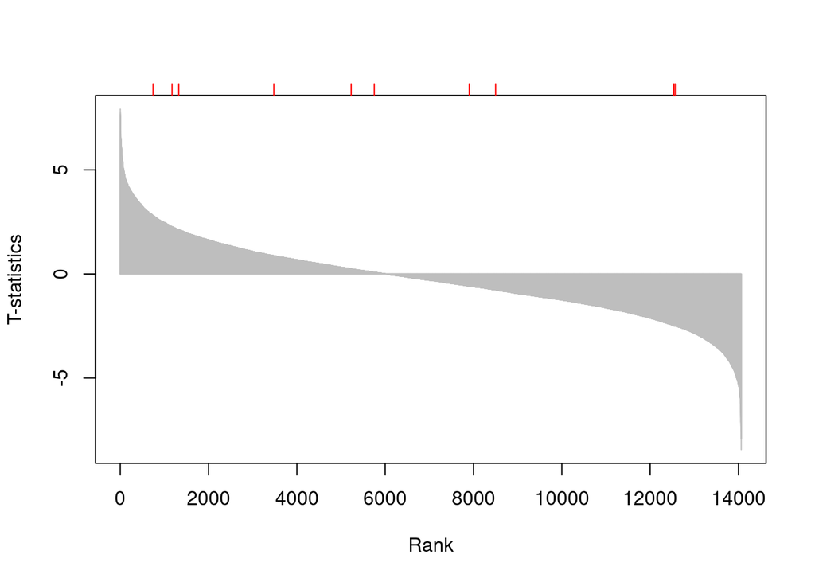

Gene rank by t-statistics. The red ticks represents the position of genes insided gene set1.

```r
plot(unname(t_stat),
  ylab = "T-statistics",
  xlab = 'Rank',
  col = 'grey',
  type ='h',
  axes  = T
)

axis(
  side = 3, at = which(rst$gs1),
  col.ticks = "red",
  labels = F
)
```

### Calculating Enrichment Score

> The score is calculated by walking down the list L, increasing a running-sum statistic when we encounter a gene in S and decreasing it when we encounter genes not in S. The magnitude of the increment depends on the correlation of the gene with the phenotype. The enrichment score is the maximum deviation from zero encountered in the random walk;

Here I use *gene set 1* as an example to illustrate the calculation of enrichment score (ES).

**Method from Mootha et al. (2003)**
$$P_{hit}(S,i)= \sum_{g_{j}{\in}S}{\sqrt{\frac{(N-N_h)}{N_h}}}$$
$$P_{miss}(S,i) =\sum_{g_{j}{\not\in}S}{ \sqrt{\frac{N_h}{(N-N_h)}}}$$

```r
n_h <- length(gs1)
n_tot <- length(t_stat)
# method1
es_neg <- -sqrt(n_h / (n_tot - n_h))
es_pos <- sqrt((n_tot - n_h) / n_h)
rst <- rst %>%
  mutate(score_gs1 = if_else(gs1, es_pos, es_neg)) %>%
  mutate(
    score_gs1=case_when(row_number()==1 ~0 , TRUE ~ score_gs1),
  es_gs1 = cumsum(score_gs1))
```

The max value of the enrichment score is 77.25

**Method from Subramanian et al. (2005)**
$$\begin{equation*}\;P_{{\mathrm{hit}}}(S,i)={{\sum_{\begin{matrix}\scriptstyle{g_{j}{\in}S}\\ \scriptstyle{j{\leq}i}\end{matrix}}}}\frac{|r_{j}|^{p}}{N_{R}},\hspace{1em}{\mathrm{where}}{\;}N_{R}={{\sum_{g_{j}{\in}S}}}|r_{j}|^{p} \end{equation*}$$
$$\begin{equation*}\;P_{{\mathrm{miss}}}(S,i)={{\sum_{\begin{matrix}\scriptstyle{g_{j}{\not\in}S}\\ \scriptstyle{j{\leq}i}\end{matrix}}}}\frac{1}{(N-N_{H})}.\;\end{equation*}$$

```r
p_miss <- -1 / (n_tot - n_h)
nr <- sum(abs(t_stat[gs1]))
rst <- rst %>%
  mutate(score2_gs1 = if_else(gs1, abs(t) / nr, p_miss)) %>%
  mutate(
    score2_gs1 = case_when(row_number() == 1 ~ 0, TRUE ~ score2_gs1),
    es2_gs1 = cumsum(score2_gs1)
  )
```

Comparison between two methods

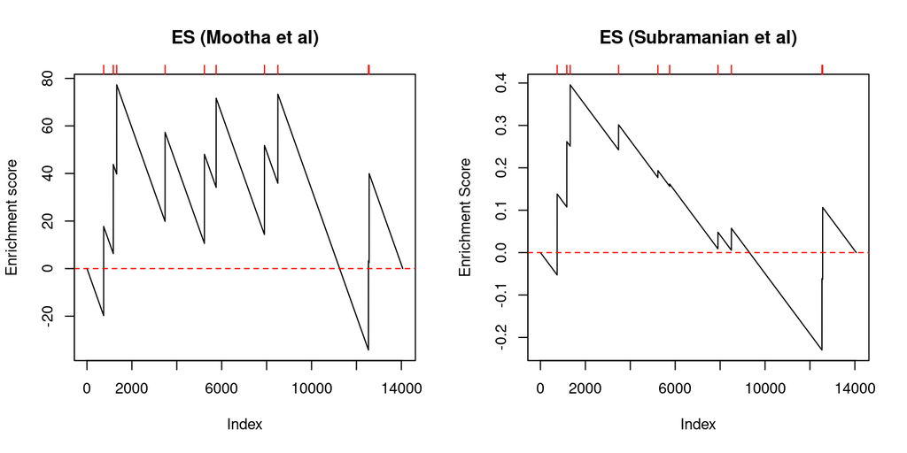

```r
  par(mfrow = c(1, 2), cex = 0.8)
  plot(rst$es_gs1, type = "l", ylab = "Enrichment score", main = "ES (Mootha et al)")
  abline(h = 0, lty = 2, col = "red")
  axis(
    side = 3, at = which(rst$gs1),
    col.ticks = "red",
    labels = F
  )
  plot(rst$es2_gs1, type = "l", ylab = "Enrichment Score", main = "ES (Subramanian et al)")
  abline(h = 0, lty = 2, col = "red")
  axis(
    side = 3, at = which(rst$gs1),
    col.ticks = "red",
    labels = F
  )
```

Similarily, I can calculate the ES for gene set 2 and gene set 3 (Figure @ref(fig:gs23) below). And one can clearly see the extreme pattern in the random walk plot due to the way that genes were selected in the sets. The Subramanian et al method panelizes the genes in the middle of rank by assigning less weight on the hits.

```r
par(mfrow = c(2, 2), cex = 0.8, mar = c(4, 4, 1, 1))
calc_enrich_score(rst, gs2, "ID", "t", "mootha")
calc_enrich_score(rst, gs3, "ID", "t", "mootha")
calc_enrich_score(rst, gs2, "ID", "t")
calc_enrich_score(rst, gs3, "ID", "t")
```

Random walk of ES for gene set 2 and 3. Upper panel with Mootha method, lower panel with Subramanian method

[figure not shown]

#### Normalized Enrichment Score (NES)

> when adjusting for variation in gene set size, we normalize the $ES(S, \pi)$ for a given S, separately rescaling the positive and negative scores by dividing by their mean value, yielding $NES(S, \pi)$ and $NES(S)$ (normalized scores, NES).

> – Supplement Subramanian et al. (2005)

Here I use gene set 1 as an example and I only illustrate the normalization procedure for the **observed ES**. Note that this is different from the NES output from the normalization of the permutated ES.

```r
rst %>%
  mutate(sign = if_else(es2_gs1> 0, T, F)) %>%
  group_by(sign) %>%
  summarise(mean_es = mean(es2_gs1))
```

```
# A tibble: 2 × 2
  sign  mean_es
  <lgl>   <dbl>
1 FALSE -0.0980
2 TRUE   0.158
```

```r
rst <- rst %>%
  mutate(sign = if_else(es2_gs1 > 0, T, F)) %>%
    mutate(nes = if_else(sign, es2_gs1 / 0.16, es2_gs1 / 0.09))
```

### Estimation of Significance Level of ES

This random walk feature correspond to [one-sample Kolmogorov–Smirnov](https://en.wikipedia.org/wiki/Kolmogorov%E2%80%93Smirnov_test#One-sample_Kolmogorov%E2%80%93Smirnov_statistic)-like statistic. In the Subramanian et al method, each step the augmentation is differentially weighted given the correlation with the profile or phenotype.

#### Kolmogorov-Smirnov Tests

> **Null hypothesis**: No gene set is associated with the class distinction – Mootha et al. (2003), where the rank ordering is used as measure of association.

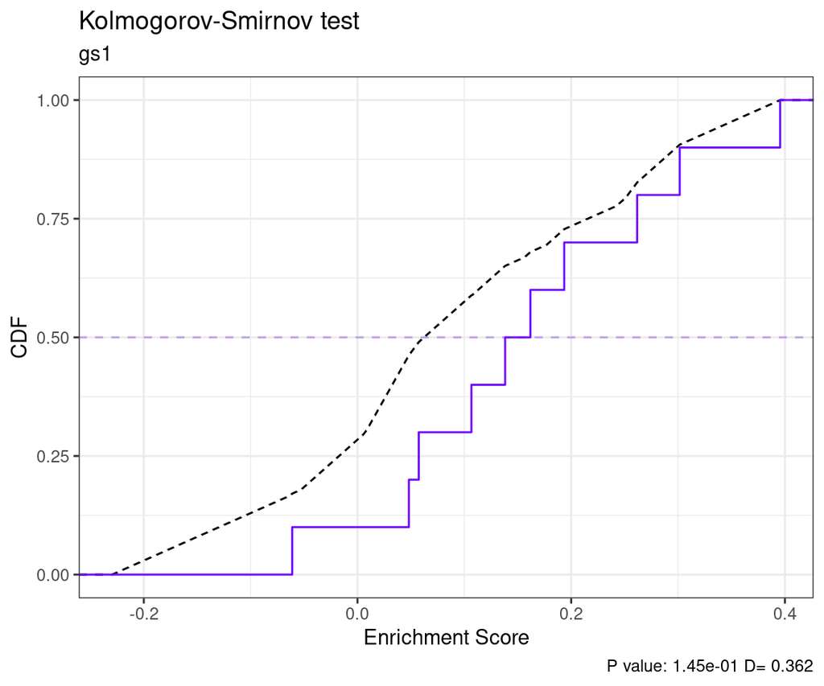

```r
ks_test_plot(rst, "ID", "es2_gs1", gs1, "gs1",
  xlab = "Enrichment Score"
)
```

#### Significance assessment

- Phenotype permutation

In Subramanian et al method, the test significance is achieved by permutation:

> We estimate the statistical significance (nominal P value) of the ES by using an empirical phenotype-based permutation test procedure that **preserves the complex correlation structure of the gene expression data**.

The phenotype is permutated and the ES scores are derived to achieve the null distribution, whereas the genetic structure is perserved. This method is wildly accepted in univariate genetic sudies. However, it turned out to be controversial and received the criticism of generating “false positive results” later on. Several methods were proposed to alleviate the intercorrelation of the genes.

- Gene sampling

In gene sampling method, a group of genes are randomly selected from the reference or background gene set to form the null gene sets. The the ES of a given gene set $S_i$ is compared against the ES formed from the null gene sets. The advantage of this method is that it does not depends on the sample size therefore can be applied to the small sample size datasets. However this method unrealistically assumes that all the genes in the dataset are independent. Another draw back of this method is that this method is computationally demanding.

### Adjustment for Multiple Hypothesis Testing.

When testing biological pathway enrichment, several gene sets are usually queried. Therefore GSEA usually involves adjustment for multiple comparisons. Classic methods are availble in the R package for addressing this issue. However, the pathways themselves can be correlated thus violating the independence assumption in many of the methods for adjusting multiple testing, such as Bonferroni, Benjamini-Hochberg. To properly adjust for multiplicity issue is an advanced topic. I will not discuss it here. A detailed discussion should be proposed elsewhere.

### Distribution of GSEA enrichment score

Unlike classic gaussian Null distribution, the null distribution of GSEA is **bimodal**.

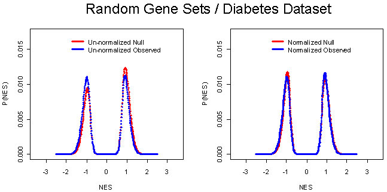

This character was addressed in the supplemental material in their paper in the section of computing statistical significance:

> **Computing Significance By Using Positive or Negative Sides of the Observed and Null Bimodal ES Distributions**

> … constructing the null by using random phenotype assignments tends to produce a more symmetric distribution that may not exactly coincide with the bulk, nonextreme part of the distribution of the observed values. To address this issue, we determine significance and adjust for multiple hypotheses testing by independently using the positive and negative sides of the observed and null bimodal ES distributions. In this way, the significance tests [nominal P value, familywise-error rate (FWER), and false discovery rate (FDR)] are single tail tests on the appropriate (positive/negative) side of the null distribution.

> – Supllemental material, Subramanian et al. (2005)

## The Leading-Edge Subset analysis.

> We define the leading-edge subset to be those genes in the gene set S that appear in the ranked list L at, or before, the point where the running sum reaches its maximum deviation from zero The leading-edge subset can be interpreted as the core of a gene set that accounts for the enrichment signal. … High scoring gene sets can be grouped on the basis of leading-edge subsets of genes that they share. Such groupings can reveal which of those gene sets correspond to the same biological processes and which represent distinct processes. – Subramanian et al. (2005)

I illustrate this idea with an example using gene set 1. Here I find the max ES in the random walk plot. I can see the ES reaches to max at gene `207479_at` then decreases. According to the definition by Subramanian et al, The leading edge genes are EIF3I, DYRK3, and 207479_at.

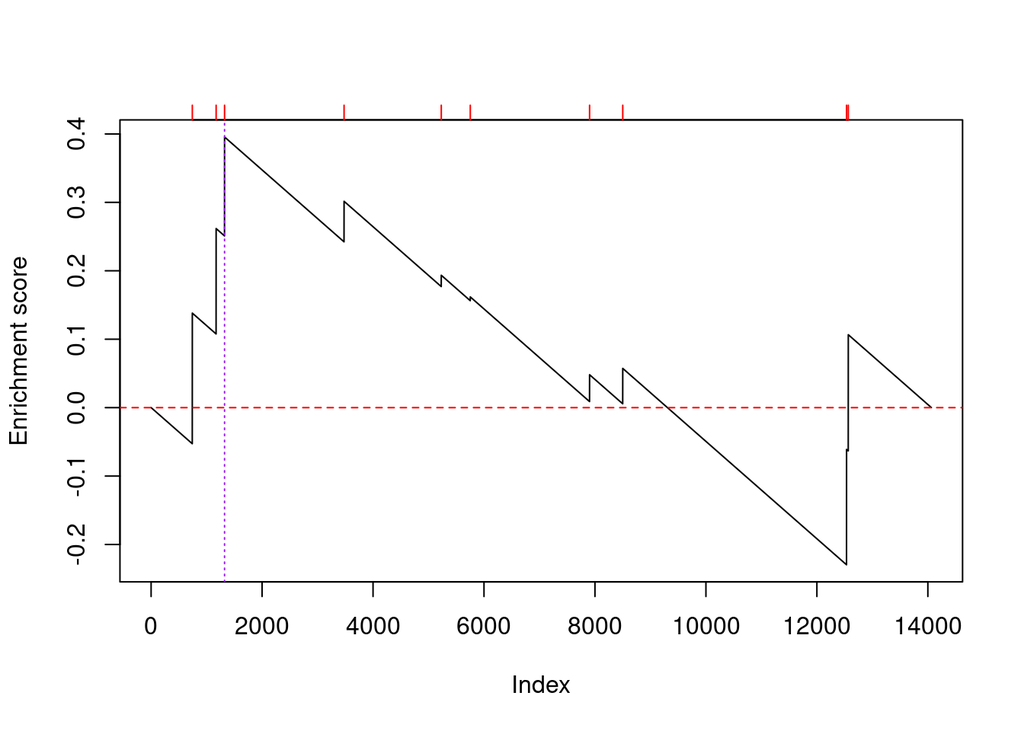

```r
calc_enrich_score(rst, gs1, "ID", "t")
abline(v = which.max(rst$es2_gs1), lty = 3, col = "purple")
```

```r
rst[rst$gs1, c("ID", "es2_gs1", "nes")]
```

[output not shown]

## GSEA using R packages

I demonstrate the GSEA with [`clusterProfiler` package](https://github.com/YuLab-SMU/clusterProfiler/tree/master) with the acknoledgement of other packages in different languages for this type of analysis such as GSEA-MSigDB.

```r
library(clusterProfiler)
library(org.Hs.eg.db)
rst <- rst %>%
  right_join(gene_ids, by = c("ID" = "hgnc_symbol")) %>%
  arrange(desc(t))
glist <- rst[, "t"] %>% setNames(rst[, "entrezgene_id"])
head(glist)
```

```
    1316     6651     9391     3916     1975    54765
7.667778 7.644064 7.567735 7.380304 7.046075 6.898707
```

### Explore biological process database

When exploring the potentially enriched pathway without prior knowledge, one can use the functions in `clusterProfiler` that prefixed with `gse*`.

**Intrepretation of results:** For a detailed explaination see [GSEA user guide](https://www.gsea-msigdb.org/gsea/doc/GSEAUserGuideFrame.html). I briefly desbribe in below.

- **Description** provides the biological description of the functionality of this pathway.
- **setSize** indicates how many genes are involved in this pathway
- **enrichmentScore** and **NES** are the enrichment score and normalized enrichment score explained above.
- **pvalue**, **p.adjust**, **qvalues** correponds to the significance test result. User can modify the methods used for multiple comparisons.
- **rank** indicates the position in the ranked list at which the maximum enrichment score occurred.
- **leading_edge**:
> - Tags. The percentage of gene hits before (for positive ES) or after (for negative ES) the peak in the running enrichment score.
> - List. The percentage of genes in the ranked gene list before (for positive ES) or after (for negative ES) the peak in the running enrichment score.
> - Signal. The enrichment signal strength that combines the two previous statistics: ${(Tag\%)(1-Gene\%)(\frac{N}{N-Nh}})$, where N is the number of genes in the list and N<sub>h</sub> is the number of genes in the gene set.

#### GO

```r
rst_go <- gseGO(
  geneList = glist,
  OrgDb = org.Hs.eg.db,
  ont = "CC",
  verbose = FALSE
)

datatable(rst_go@result)
```

|  | ID | Description | setSize | enrichmentScore | NES | pvalue | p.adjust | qvalues | rank | leading_edge | core_enrichment |
| --- | --- | --- | --- | --- | --- | --- | --- | --- | --- | --- | --- |
| GO:0030312 | GO:0030312 | external encapsulating structure | 436 | -0.35716572780755 | -1.77720498316457 | 1.52612564138124e-08 | 5.07436775759261e-06 | 4.53018348283693e-06 | 3604 | tags=39%, list=29%, signal=29% | 51129/43/1359/157869/1634/811/7373/2200/81577/1000/3383/3730…… |
| GO:0031012 | GO:0031012 | extracellular matrix | 436 | -0.35716572780755 | -1.77720498316457 | 1.52612564138124e-08 | 5.07436775759261e-06 | 4.53018348283693e-06 | 3604 | tags=39%, list=29%, signal=29% | 51129/43/1359/157869/1634/811/7373/2200/81577/1000/3383/3730…… |
| GO:0062023 | GO:0062023 | collagen-containing extracellular matrix | 345 | -0.362102932092686 | -1.76218248856956 | 4.46791898540784e-07 | 9.90388708432071e-05 | 8.84177651849131e-05 | 3604 | tags=40%, list=29%, signal=29% | 51129/43/1359/157869/1634/811/7373/2200/1000/3383/197/3914/4…… |
| GO:0099023 | GO:0099023 | vesicle tethering complex | 49 | 0.532744345023689 | 2.12331328067949 | 3.44637027603457e-05 | 0.00572959058390747 | 0.00511513904127236 | 2738 | tags=51%, list=22%, signal=40% | 10640/23265/9392/25839/738/55770/27095/26276/55275/55823/29911/64601/22796/60684/22878/11336/10597/51542/23339/55763/51112/51693/51361/23355/23233 |
| GO:0009897 | GO:0009897 | external side of plasma membrane | 273 | -0.325550696520602 | -1.55758650744415 | 0.000121142160681012 | 0.0161119073705746 | 0.0143840376050718 | 3725 | tags=40%, list=30%, signal=29% | 23627/5340/1233/2675/5034/3560/811/6403/2676/972/1232/2683/6…… |
| GO:0018995 | GO:0018995 | host cellular component | 55 | 0.477021216745957 | 1.96819271468782 | 0.000191963686057601 | 0.0182327365241065 | 0.0162774252466895 | 2047 | tags=40%, list=16%, signal=34% | 9397/4928/5903/79902/3836/7514/23511/5297/8480/81929/55706/9972/8086/23633/23165/51160/348995/9631/57122/7311/55746/358 |
| GO:0043657 | GO:0043657 | host cell | 55 | 0.477021216745957 | 1.96819271468782 | 0.000191963686057601 | 0.0182327365241065 | 0.0162774252466895 | 2047 | tags=40%, list=16%, signal=34% | 9397/4928/5903/79902/3836/7514/23511/5297/8480/81929/55706/9972/8086/23633/23165/51160/348995/9631/57122/7311/55746/358 |
| GO:0016607 | GO:0016607 | nuclear speck | 337 | 0.273839531717131 | 1.4689185038779 | 0.000219341191267447 | 0.0182327365241065 | 0.0162774252466895 | 2289 | tags=28%, list=18%, signal=24% | 6651/55671/4208/81669/23451/29883/7994/5300/24148/50809/9360…… |
| GO:0005796 | GO:0005796 | Golgi lumen | 83 | -0.434897244913546 | -1.78753909380975 | 0.00043809151516582 | 0.0323700952872522 | 0.028898668368833 | 3228 | tags=42%, list=26%, signal=31% | 5627/83452/351/375790/3630/2331/1081/2159/63827/7477/4803/2158/4583/176/8074/3906/7474/4325/2719/4586/7040/56667/50512/653808/4323/5154/1462/1672/23759/4584/6385/633/2817/4043/2155 |

#### WikiPathways

```r
rst_wp <- gseWP(glist, organism = "Homo sapiens")
datatable(rst_wp@result)
```

|  | ID | Description | setSize | enrichmentScore | NES | pvalue | p.adjust | qvalues | rank | leading_edge | core_enrichment |
| --- | --- | --- | --- | --- | --- | --- | --- | --- | --- | --- | --- |
| WP23 | WP23 | B cell receptor signaling pathway | 93 | 0.462303897032088 | 2.08609165051133 | 1.87932705181941e-06 | 0.00119337267790533 | 0.00109594440706101 | 1579 | tags=33%, list=13%, signal=29% | 4208/2969/5294/2308/10892/1399/5781/7410/5594/4790/1385/6850/1386/8517/25780/2002/6654/3662/3635/8462/2889/3551/5894/974/640/1398/2113/5336/7409/4609/5296 |
| WP411 | WP411 | mRNA processing | 113 | 0.409618246825284 | 1.887222634319 | 3.84461037321918e-05 | 0.0122066379349709 | 0.0112100744566496 | 1704 | tags=32%, list=14%, signal=28% | 6433/23451/10181/24148/11051/8899/1659/10250/6432/1196/10594/1478/5725/6733/8106/6628/8405/8732/4670/1665/51362/6633/10659/51690/3276/10291/10898/57396/10972/6428/9785/6636/8449/23450/1479/5496 |
| WP455 | WP455 | GPCRs, class A rhodopsin-like | 220 | -0.35506724756263 | -1.65951365928798 | 9.43554811632247e-05 | 0.0199719101795492 | 0.018341381250676 | 3706 | tags=39%, list=30%, signal=28% | 81797/1233/185/23596/2848/154/2925/4995/1232/10316/2866/2841…… |
| WP437 | WP437 | EGF/EGFR signaling pathway | 153 | 0.344250505436043 | 1.68133765013444 | 0.000191927174995584 | 0.0273231925120644 | 0.0250924967288582 | 1732 | tags=27%, list=14%, signal=24% | 4208/6774/10928/2308/5868/1399/5781/7410/4214/10746/5594/508…… |
| WP4921 | WP4921 | Mitochondrial complex III assembly | 11 | 0.775466077804268 | 2.10332359966327 | 0.000215143248126492 | 0.0273231925120644 | 0.0250924967288582 | 1499 | tags=64%, list=12%, signal=56% | 27089/55245/7384/1537/7386/29796/617 |
| WP5269 | WP5269 | Genetic causes of porto-sinusoidal vascular disease | 28 | 0.596389903026489 | 2.03296444670992 | 0.000554711823645901 | 0.046290320165238 | 0.0425111270145741 | 1054 | tags=29%, list=8%, signal=26% | 1536/2969/1716/5594/4790/51142/6667/285203 |
| WP2806 | WP2806 | Complement system | 92 | -0.423346153749385 | -1.72810969648705 | 0.000640146475381125 | 0.046290320165238 | 0.0425111270145741 | 3586 | tags=46%, list=29%, signal=33% | 1634/811/6403/3383/2244/5627/3912/3080/213/2159/5199/3915/55…… |
| WP3915 | WP3915 | Angiopoietin-like protein 8 regulatory pathway | 125 | 0.347256265060405 | 1.63087256487505 | 0.000656969990338012 | 0.046290320165238 | 0.0425111270145741 | 1692 | tags=28%, list=14%, signal=24% | 5294/2308/4214/6199/10746/5594/9020/2309/23265/5562/5293/5565/5564/64240/6655/6654/5290/30849/79109/2889/5894/6567/4216/6517/10062/1398/2194/6720/5603/5296/6416/6197/6721/5607/25759 |
| WP313 | WP313 | Hepatocyte growth factor receptor signaling | 34 | 0.533323140388801 | 1.89391323597216 | 0.000670811129024907 | 0.046290320165238 | 0.0425111270145741 | 1475 | tags=38%, list=12%, signal=34% | 6774/1399/5781/5594/2002/6654/5290/2889/5894/3688/1398/5728/5058 |
| WP2877 | WP2877 | Vitamin D receptor pathway | 152 | -0.363634006499809 | -1.60371840101489 | 0.000728981419925007 | 0.046290320165238 | 0.0425111270145741 | 3257 | tags=40%, list=26%, signal=30% | 3663/147/6279/1647/26239/1992/1591/25928/4041/79689/595/3484…… |

#### Reactome

```r
rst_react <- ReactomePA::gsePathway(glist)
datatable(rst_react@result)
```

|  | ID | Description | setSize | enrichmentScore | NES | pvalue | p.adjust | qvalues | rank | leading_edge | core_enrichment |
| --- | --- | --- | --- | --- | --- | --- | --- | --- | --- | --- | --- |
| R-HSA-5689880 | R-HSA-5689880 | Ub-specific processing proteases | 143 | 0.406466339981796 | 1.96193395339431 | 2.2569689646653e-06 | 0.00323649349533004 | 0.00282477484103899 | 2380 | tags=37%, list=19%, signal=30% | 5688/8078/10197/57599/9100/5705/29761/7375/8517/4194/23032/8…… |
| R-HSA-500792 | R-HSA-500792 | GPCR ligand binding | 372 | -0.332371984096122 | -1.62361353372066 | 4.62168329529113e-06 | 0.00331374692272374 | 0.00289220075689534 | 3726 | tags=36%, list=30%, signal=26% | 183/2921/1233/185/23596/2641/23566/154/2791/6360/2925/7200/1…… |
| R-HSA-373076 | R-HSA-373076 | Class A/1 (Rhodopsin-like receptors) | 273 | -0.354483520404548 | -1.6927528501345 | 1.24561520591803e-05 | 0.0059540406842882 | 0.00519661922749664 | 3850 | tags=41%, list=31%, signal=29% | 3576/1909/4922/2829/183/2921/1233/185/23596/23566/154/6360/2…… |
| R-HSA-1169410 | R-HSA-1169410 | Antiviral mechanism by IFN-stimulated genes | 72 | 0.46854766624195 | 2.01585954206268 | 2.21351686276689e-05 | 0.00793545795301929 | 0.00692597776271008 | 2007 | tags=40%, list=16%, signal=34% | 5300/4928/6059/5903/3841/6041/79902/3836/23511/5495/1981/8480/25820/4734/81929/55706/9972/8086/3716/4939/23165/348995/9631/2317/57122/7311/3840/5610/55746 |
| R-HSA-3000178 | R-HSA-3000178 | ECM proteoglycans | 72 | -0.494142095626788 | -1.94668112797847 | 3.17550503111745e-05 | 0.00910734842924483 | 0.00794879048841819 | 3136 | tags=49%, list=25%, signal=37% | 351/375790/3912/2331/63827/3915/1284/176/1277/63923/50509/1289/1281/3911/1278/7040/3909/7148/7143/1299/3908/4684/1404/1462/3673/3381/54829/3674/1298/8785/6678/1311/3687/633/1834 |
| R-HSA-1474244 | R-HSA-1474244 | Extracellular matrix organization | 263 | -0.339690752054915 | -1.61012349897838 | 7.91772865070807e-05 | 0.0182732162835689 | 0.0159486560677996 | 2781 | tags=37%, list=22%, signal=30% | 5340/4146/5034/1756/1634/7373/8516/2200/999/3383/3914/2244/4…… |
| R-HSA-72203 | R-HSA-72203 | Processing of Capped Intron-Containing Pre-mRNA | 200 | 0.323726131780593 | 1.65483582204289 | 8.91998005474074e-05 | 0.0182732162835689 | 0.0159486560677996 | 2322 | tags=34%, list=19%, signal=28% | 10523/23451/10181/24148/11051/5439/4928/5903/11193/10250/643…… |
| R-HSA-168276 | R-HSA-168276 | NS1 Mediated Effects on Host Pathways | 37 | 0.5695045174852 | 2.09808560609309 | 0.000122898498419013 | 0.0219263190634356 | 0.0191370427706268 | 2007 | tags=54%, list=16%, signal=46% | 4928/5903/3841/79902/3836/8106/23511/8480/81929/55706/9972/8086/23165/10898/348995/9631/57122/3840/5610/55746 |
| R-HSA-5688426 | R-HSA-5688426 | Deubiquitination | 203 | 0.322300129729832 | 1.65168292212023 | 0.000137612881151269 | 0.0219263190634356 | 0.0191370427706268 | 2387 | tags=33%, list=19%, signal=27% | 5688/8078/8473/10197/57599/9100/7048/5705/29761/79155/29086/…… |
| R-HSA-72306 | R-HSA-72306 | tRNA processing | 83 | 0.413951801214386 | 1.8260368086465 | 0.00017233459735212 | 0.0242625469736364 | 0.0211760760123715 | 2427 | tags=37%, list=19%, signal=30% | 23536/51367/4928/5903/54901/51504/79902/10248/1478/23511/8480/55621/81929/55706/9972/10556/8086/23165/10898/25821/348995/8270/9631/1787/57122/221078/55746/9836/79074/9818/10775 |

[output cut: 4 more lines]

#### DO

```r
gseDO(glist)
```

```
#
# Gene Set Enrichment Analysis
#
#...@organism    Homo sapiens
#...@setType     DO
#...@keytype     ENTREZID
#...@geneList    Named num [1:12491] 7.67 7.64 7.57 7.38 7.05 ...
 - attr(*, "names")= chr [1:12491] "1316" "6651" "9391" "3916" ...
#...nPerm
#...pvalues adjusted by 'BH' with cutoff <0.05
#...0 enriched terms found
'data.frame':   0 obs. of  8 variables:
 $ ID             : chr
 $ Description    : chr
 $ setSize        : int
 $ enrichmentScore: num
 $ NES            : num
 $ pvalue         : num
 $ p.adjust       : num
 $ qvalues        : num
#...Citation
  Guangchuang Yu, Li-Gen Wang, Guang-Rong Yan, Qing-Yu He. DOSE: an
  R/Bioconductor package for Disease Ontology Semantic and Enrichment
  analysis. Bioinformatics 2015, 31(4):608-609
```

#### KEGG

There’s a [bug](https://github.com/YuLab-SMU/clusterProfiler/issues/561) in the order `clusterProfiler` package.do It is recommended to update R version and `DOSE` package. I won’t be able illustrate this in my local setting.

```r
g_ensl <- rst[, "t"] %>% setNames(rst[, "ensembl_gene_id"])
rst_kegg <- gseKEGG(
  geneList = g_ensl,
  organism = "hsa",
  keyType = 'ncbi-geneid',
  verbose = FALSE
)
head(rst_kegg)
```

### Test preselected pathway

One can use `GSEA` function to test preselected pathways. Here I use gene set1 as an example.

There are two options for performing GSEA:

- The classical GSEA procedure which performs permutation and takes long time. This can be specified in the `by ='DOSE'` argument.
- Or the fast-GSEA by Korotkevich et al. (2016) , which can be specified in `by = 'fgsea'`.

```r
gs1_id <- rst[which(rst$ID %in% gs1), "entrezgene_id", drop = F] %>%
  mutate(gs.name = "Siying's random set") %>%
  relocate(gs.name, .before = entrezgene_id)

head(gs1_id)
```

```
                 gs.name entrezgene_id
700  Siying's random set          8668
1089 Siying's random set          8444
3194 Siying's random set         55180
4752 Siying's random set          6563
5207 Siying's random set         27244
7137 Siying's random set         80006
```

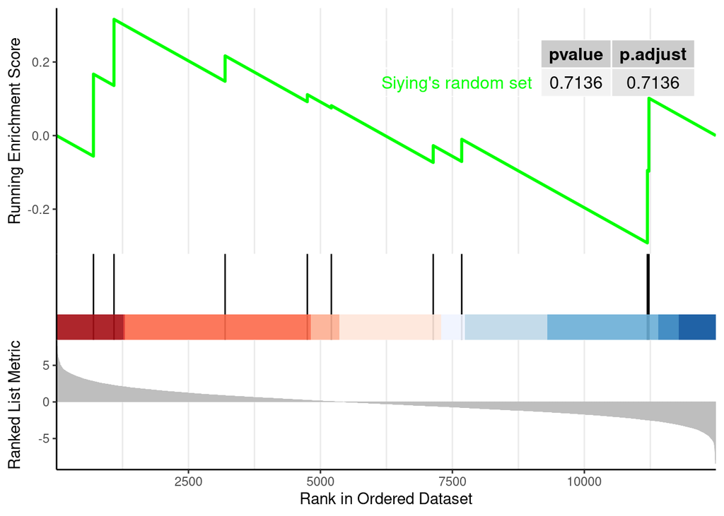

```r
rst_gsea <- GSEA(glist,
  minGSSize = 1,
  TERM2GENE = gs1_id,
  pvalueCutoff = 1,
  by = "fgsea",
  nPerm = 1000
)

gseaplot2(rst_gsea,
  geneSetID = 1,
  pvalue_table = T
)
```

## Pros and Cons

- Able to see the direction of pathway regulation
- Some complained that KS test is not sensitive, the others complain about the correlations among genes in a patwhay would render *“false positive”* results.

## Reference

Korotkevich, Gennady, Vladimir Sukhov, Nikolay Budin, Boris Shpak, Maxim N. Artyomov, and Alexey Sergushichev. 2016. “Fast Gene Set Enrichment Analysis.” Preprint. Bioinformatics. https://doi.org/10.1101/060012.

Mootha, Vamsi K., Cecilia M. Lindgren, Karl-Fredrik Eriksson, Aravind Subramanian, Smita Sihag, Joseph Lehar, Pere Puigserver, et al. 2003. “PGC-1alpha-Responsive Genes Involved in Oxidative Phosphorylation Are Coordinately Downregulated in Human Diabetes.” *Nature Genetics* 34 (3): 267–73. https://doi.org/10.1038/ng1180.

Subramanian, Aravind, Pablo Tamayo, Vamsi K. Mootha, Sayan Mukherjee, Benjamin L. Ebert, Michael A. Gillette, Amanda Paulovich, et al. 2005. “Gene Set Enrichment Analysis: A Knowledge-Based Approach for Interpreting Genome-Wide Expression Profiles.” *Proceedings of the National Academy of Sciences* 102 (43): 15545–50. https://doi.org/10.1073/pnas.0506580102.